# SU_DA1_阿部大空_期末レポート

Sora abe

2023-08-03

- 使用するパッケージを読み込む

```r
library(tidyverse)
library(DT)
library(stargazer)
library(ggrepel)
library(gghighlight)
```

# (1)関心のあるテーマと「データサイエンス」的な仮説

## 自分が関心のあるテーマ

自分が関心のあるテーマは「格差」である。 gooddoマガジン(2022)によると国の格差は広がっており、日本もそれに漏れていないと記述されている。また、東洋経済オンライン(2020)では「日本人は｢格差拡大｣の深刻さをわかっていない」という不安を煽るようなタイトルの記事が載せられている。日本の格差はどの程度深刻なのだろうか？

飯田(2020)では国の格差の指標としてジニ係数が便利であることを示している。ジニ係数は所得の格差を示すために有用で社会学・経済学のさまざまな場面で使われる係数である。 このことより、本レポートではジニ係数を格差として考えていきたい。

樋口(2006)ではジニ係数について次のように述べている。「すなわちわが国では80年代以降、所得格差を示す指標であるジニ係数は、格差拡大傾向を示しているが、最近の研究によると、その主たる要因は「真の格差拡大」というよりも、世帯主の高齢化や単身世帯など少人数世帯の増加にあるといえそうである。」 世帯主の高齢化によってジニ係数が増える可能性があるようである。

ジニ係数と高齢化について興味深い論争を見つけた。「橘木大竹論争」である。wikipedia(2022)によると橘木大竹論争は格差は拡大していると主張する橘木氏とそれは高齢化によりジニ係数が高くなったからであり、いわゆる格差が広がって問題になっているのとは少し違うという指摘をした大竹氏の一連の論争のことである。それぞれの主張はそれぞれの著書に載っており自分はそれを入手・閲覧できる環境にいなかったため参考文献に第一次資料を載せることはできなかったが、その周辺のインターネット等で得られた資料で考察していく。宇仁(2007)において大竹氏や内閣府は1990年代の格差拡大の主な要因は人口高齢化であり、このような不平等化は真の不平等化とはいえないと主張したと記述されている。ここで行われた分析として日本を階層別に分けて考えていた。私はこの事象について世界的に起こり得るのかということについて興味を持った。大島(2010)では、「ジニ係数上昇の要因については橘木氏は大竹氏や政府の見解を受け入れた。両者の見解は収斂に向かったと言える。」(一部改変)とあった。以上のことから橘木大竹論争は終わったと言える。内野・菅原(2017)にも国内のジニ係数について高齢化の影響が示唆されている。しかし、世界的にこの現象が認められるのかということについては資料が見当たらなかった。これらのことより私は「少子高齢化によりジニ係数は上昇するか」について世界規模で起こっているかどうか調べていきたい。

厚生労働省(2006)によると少子高齢化により年代別の所得に格差の開きが生じ、その結果ジニ係数が上昇するという流れでこのような時結果が起きていると言われている。よってこの仮説は原因の時間的先行と少子高齢化の数値を65歳以上の人口の割合と設定しすることで原因と結果の共変関係も満たしている。

## コントロール変数の考慮

鈴木(2006)によると賃金格差には、地域の産業・企業規模別の分布が影響を与えると考えられる。また、宇仁(2007)では男女間の格差や学歴格差等によってジニ係数は変動する可能性が指摘されている。それに加え賃金の格差にはその国の政策が関わってくることは自明であり、もしその国が独裁国家であった場合や経済状況によって65歳以上の割合関係なくジニ係数は増大するだろう。

よって以上のことより独立変数を65歳以上の人口の割合と設定し、コントロール変数を産業や企業規模の分布、男女間の格差や学歴格差と設定する。

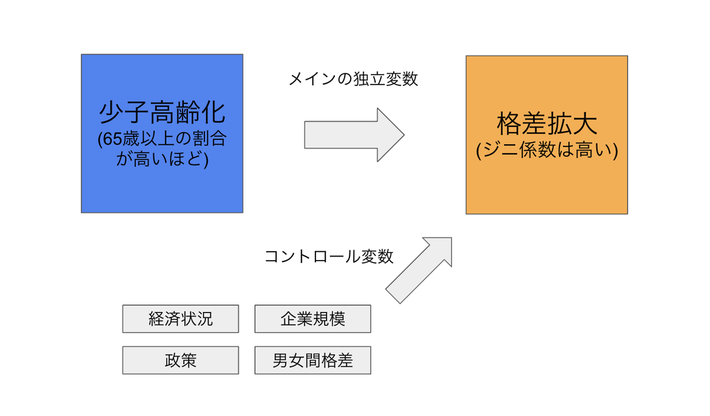

符号条件の図